# AZ OpenGIS Data Exploration

# Appendix B: Reading in Data

Consistent with efforts to master principles of reproducible research, one of my goals was read the Humane Borders fatalities data set directly from the web into R and ultimately ArcGIS. In the past, my practice involved downloading a CVS file from the website and then reading this file into an application from the local disk. Turns out that some hidden transformations occurred along the way that I never really noticed until I tried reading the CSV file directly from an API request sent to the server.

When I pulled the data directly from the server using an API request URL I got one record fewer than if I saved the CSV file to the local disk and inspected it. Turns out that opening a CSV file in excel strips out quotation marks which can result in some unexpected results. In this case, opening the file in Excel resolved one issue that caused R to read in the proper number of records. However, Excel’s silent removal of quotation marks causes problems properly interpreting diacritical characters. This is an issue because several names contain characters like: á, í, ñ, etc. Though initially, the raw file was not read properly by R I believe it is better to avoid opening the file in Excel. Fortunately, there are functions within R that can help identify the problems with the file. Generally, when working with CSV data, I believe it is better to inspect the file with a text editor like Notepad++ or Atom that will not make silent changes to the data structure.

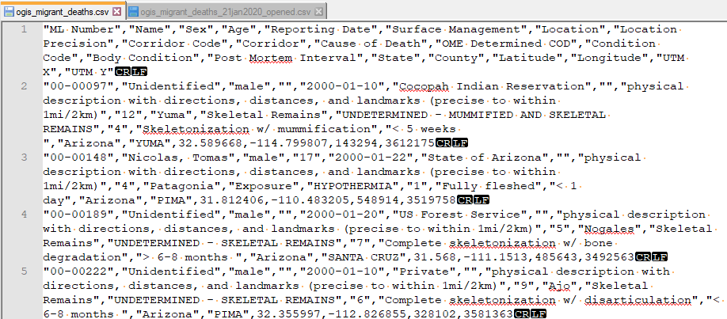

Figure 7.1: Raw CSV file downloaded directly from server and opened with Notepad++

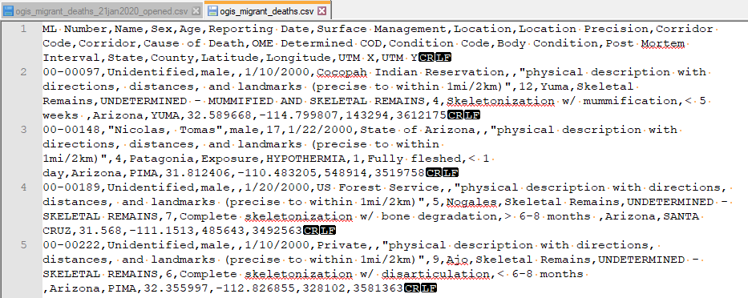

I submitted the api request url to an online [testing](https://reqbin.com/) tool. The data returned contained the missing record. Therefore, the server is sending the record. It seems like the record is dropped during the read stage. I copied the text from the testing tool into a file, named it csv. That file contains the missing record. When I read it with `read_csv()` the record was missing.

Using the `problems()` function helped to pretty quickly identify the issue. Turns out there is an extra quotation mark in one of the field of record `04-01085 GOMEZ HERRERA, ISMAEL`. In the `df_csv_api` this is line number 541.

The error is in the file being sent from the server. The added quote mark does not raise an issue with Excel, but it will raise an issue with other programs. The text in question is `"HYPERTHERMIA; AS A CONSEQUENCE OF\" EXPOSURE TO THE ELEMENTS"` I believe it is the excaped quote that causses the problem.

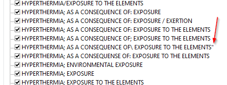

[figure not shown]

I took a fresh copy of the file and opened it in Notepad++ and removed `\"` from line 541.

For line 541, one of the fields originally reads: `"Exposure","HYPERTHERMIA; AS A CONSEQUENCE OF\" EXPOSURE TO THE ELEMENTS"`

It should read: `"Exposure","HYPERTHERMIA; AS A CONSEQUENCE OF EXPOSURE TO THE ELEMENTS"`

After doing this the file reads properly into ArcGIS. It can be import as a CSV which sidesteps the problem with Excel messing with the names. The change to the file also makes it possible to properly read into R and Excel.

I’m not sure how to deal with this programmatically. Ideally, the escaped quote would be taken out of the original data. In the mean time, I can make a note to myself to fix this record.